# subsidyexploration

```python
conda install -c conda-forge pandoc
```

[output not shown]

[output cut: 18 more lines]

[output not shown]

```python
#Some packages need downloading everytime on this environment:

%pip install seaborn
%pip install missingno
%pip install -U scikit-learn
%pip install openpyxl
%pip install lets-plot
%pip install wordcloud
```

```python
# Data manipulation/visualisation libraries
import pandas as pd
import numpy as np
import matplotlib.pyplot as plt
import seaborn as sns
import missingno as msno
from lets_plot import *
LetsPlot.setup_html()
#Machine Learning libraries
from sklearn.model_selection import train_test_split, cross_val_score, GridSearchCV
from sklearn.preprocessing import StandardScaler, MinMaxScaler, LabelEncoder, OneHotEncoder
from sklearn.linear_model import LinearRegression, LogisticRegression
from sklearn.tree import DecisionTreeClassifier
from sklearn.ensemble import RandomForestClassifier, GradientBoostingClassifier
from sklearn.svm import SVC
from sklearn.neighbors import KNeighborsClassifier
from sklearn.cluster import DBSCAN
from sklearn.preprocessing import StandardScaler
from sklearn.preprocessing import OneHotEncoder
from sklearn.cluster import KMeans
from sklearn.decomposition import PCA
from sklearn.ensemble import IsolationForest
from sklearn.preprocessing import LabelEncoder
```

## 📊 UK Subsidy Data Analysis

This project explores and analyses the UK Subsidy Award and Scheme datasets with a focus on transparency, policy relevance, and data-driven insights. The work is grounded in thorough data cleaning, transformation, and exploratory data analysis (EDA), using Python and pandas to uncover patterns in how public subsidies have been distributed across sectors, regions, and time.

Key areas of analysis include:

- Trends in subsidy amounts and counts over time, especially during the COVID-19 interim period (2021–2023)
- Breakdown of subsidies by purpose (`simplified_category`), recipient size, and form
- Identification of outliers and anomalies in award values
- Reproduction of key statistics from official government reports
- Visual summaries such as area plots, heatmaps, and word clouds to communicate findings clearly

The notebook is designed to be reproducible and well-documented, making it a useful reference for analysts, researchers, and anyone interested in UK public finance and subsidy transparency.

> 📁 Data Source: UK Government Subsidy Transparency Database

```python
#Read in the data
df = pd.read_excel('publicsearchawards.xlsx', engine='openpyxl')
```

```python
df
```

|  | Standalone award | Subsidy control number | Subsidies or Schemes of Interest (SSoI) or Subsidies or Schemes of Particular Interest (SSoPI) | Specific policy objective | Subsidy award description | Public authority URL | Public authority URL Description | Subsidy award number | Subsidy award status | Subsidy scheme name | ... | Created date | Last modified date | Comments | Recipient name | Recipient size | ID type | ID number | Goods or services | Spending region(s) | Spending sector |
| --- | --- | --- | --- | --- | --- | --- | --- | --- | --- | --- | --- | --- | --- | --- | --- | --- | --- | --- | --- | --- | --- |
| 0 | No | SC11297 | NaN | NaN | ISLANDS DEAL Desination Development - Calanais... | NaN | NaN | 39747 | Published | HIE Community Empowerment Subsidy Scheme | ... | 02 July 2025 | 02 July 2025 | NaN | Urras nan Tursachan | SME | Charity Number | 22483 | Services | Scotland | Arts, entertainment and recreation |
| 1 | No | SC10737 | NaN | NaN | Capital investment - main access chairlift\nLe... | NaN | NaN | 39745 | Published | HIE Economic Development Subsidy Scheme 2022 -... | ... | 02 July 2025 | 02 July 2025 | NaN | Glencoe Mountain Limited | SME | Company Registration Number | SC346505 | Services | Scotland | Arts, entertainment and recreation |
| 2 | No | SC10773 | NaN | NaN | The legal basis for the subsidy award is the U... | NaN | NaN | 39744 | Published | Levelling Up Fund Subsidy Scheme | ... | 02 July 2025 | 02 July 2025 | NaN | North Ayrshire Council | Large | VAT Number | 659289771 | Services | Scotland | Real estate activities |
| 3 | No | SC11297 | NaN | NaN | Community sports education hub extension - thi... | NaN | NaN | 39746 | Published | HIE Community Empowerment Subsidy Scheme | ... | 02 July 2025 | 02 July 2025 | NaN | Inverness Caledonian Thistle Community Develop... | SME | Company Registration Number | SC276155 | Services | Scotland | Human health and social work activities |
| 4 | No | SC11294 | NaN | NaN | Grant i Menter Iaith Casnewydd i hybu a hyrwyd... | NaN | NaN | 39735 | Published | Cymraeg 2050 | ... | 01 July 2025 | 01 July 2025 | NaN | Menter Iaith Casnewydd | SME | Charity Number | 1187868 | Services | Wales | Arts, entertainment and recreation |
| ... | ... | ... | ... | ... | ... | ... | ... | ... | ... | ... | ... | ... | ... | ... | ... | ... | ... | ... | ... | ... | ... |
| 32126 | No | SC10328 | NaN | NaN | NaN | NaN | NaN | 370 | Published | Getting Building Fund | ... | 16 July 2021 | 16 July 2021 | NaN | Manchester Science Partnerships Limited | Large (more than 250 employees) | Company Registration Number | 01717239 | Services | North West | Professional, scientific and technical activities |
| 32127 | No | SC10328 | NaN | NaN | NaN | NaN | NaN | 418 | Published | Getting Building Fund | ... | 09 August 2021 | 09 August 2021 | NaN | Mayfield Development Partnership LP | Medium (between 50 and 249 employees) | Company Registration Number | LP017769 | Services | North West | Real estate activities |
| 32128 | No | SC10172 | NaN | NaN | NaN | NaN | NaN | 166 | Published | Heat Networks Investment Project | ... | 29 March 2021 | 29 March 2021 | NaN | Kent County Council | Large (more than 250 employees) | VAT Number | 204269191 | Services | South East | Electricity, gas, steam and air conditioning s... |
| 32129 | No | SC11262 | NaN | NaN | The subsidy award is to support affordable hom... | NaN | NaN | 39514 | Published | Construction Skills through Regeneration | ... | 02 June 2025 | 02 June 2025 | NaN | Walsall Housing Group Limited | Large | Company Registration Number | 04015633 | Services | West Midlands | Real estate activities |
| 32130 | No | SC10327 | NaN | NaN | NaN | NaN | NaN | 366 | Published | NorthLink & Calmac | ... | 12 July 2021 | 12 July 2021 | NaN | NorthLink & Calmac | Large (more than 250 employees) | VAT Number | 889051388 | Services | Scotland | Transportation and storage |

32131 rows × 28 columns

Cleaning up some of the names:

```python
dtype_mapping = {
    'Standalone award': 'string',
    'Subsidy control number': 'string',
    'Subsidies or Schemes of Interest (SSoI) or Subsidies or Schemes of Particular Interest (SSoPI)': 'string',
    'Specific policy objective': 'string',
    'Subsidy award description': 'string',
    'Public authority URL': 'string',
    'Public authority URL Description': 'string',
    'Subsidy award number': 'string',
    'Subsidy award status': 'string',
    'Subsidy scheme name': 'string',
    'Services of Public Economic Interest (SPEI)': 'string',
    'Subsidy purpose': 'string',
    'Subsidy form': 'string',
    'Subsidy element full amount/£': 'float',
    'Subsidy element full amount range/£': 'string',
    'Public authority name': 'string',
    'Awarded date': 'datetime64[ns]',
    'Published date': 'datetime64[ns]',
    'Created date': 'datetime64[ns]',
    'Last modified date': 'datetime64[ns]',
    'Comments': 'string',
    'Recipient name': 'string',
    'Recipient size': 'string',
    'ID type': 'string',
    'ID number': 'string',
    'Goods or services': 'string',
    'Spending region(s)': 'string',
    'Spending sector': 'string'
}
```

```python
#Cleaning up the data types and datetimes

def clean_data_types(df):
    for col, dtype in dtype_mapping.items():
        if col in df.columns:
            if dtype.startswith('datetime'):
                df[col] = pd.to_datetime(df[col], errors='coerce')
            else:
                df[col] = df[col].astype(dtype, errors='ignore')
    return df
```

```python
# Renaming the column names for easier code readability

df = df.rename(columns={
    'Standalone award': 'standalone_award',
    'Subsidy control number': 'subsidy_num',
    'Subsidies or Schemes of Interest (SSoI) or Subsidies or Schemes of Particular Interest (SSoPI)': 'subsidy_type',
    'Specific policy objective': 'policy_objective',
    'Subsidy award description': 'award_description',
    'Public authority URL': 'authority_url',
    'Public authority URL Description': 'authority_url_description',
    'Subsidy award number': 'award_num',
    'Subsidy award status': 'award_status',
    'Subsidy scheme name': 'scheme_name',
    'Services of Public Economic Interest (SPEI)': 'spei',
    'Subsidy purpose': 'subsidy_purpose',
    'Subsidy form': 'subsidy_form',
    'Subsidy element full amount/£': 'amount_full',
    'Subsidy element full amount range/£': 'amount_range',
    'Public authority name': 'authority_name',
    'Awarded date': 'awarded_date',
    'Published date': 'published_date',
    'Created date': 'created_date',
    'Last modified date': 'last_modified_date',
    'Comments': 'comments',
    'Recipient name': 'recipient_name',
    'Recipient size': 'recipient_size',
    'ID type': 'id_type',
    'ID number': 'id_number',
    'Goods or services': 'goods_or_services',
    'Spending region(s)': 'spending_regions',
    'Spending sector': 'spending_sector'
})
```

```python
df
```

|  | standalone_award | subsidy_num | subsidy_type | policy_objective | award_description | authority_url | authority_url_description | award_num | award_status | scheme_name | ... | created_date | last_modified_date | comments | recipient_name | recipient_size | id_type | id_number | goods_or_services | spending_regions | spending_sector |
| --- | --- | --- | --- | --- | --- | --- | --- | --- | --- | --- | --- | --- | --- | --- | --- | --- | --- | --- | --- | --- | --- |
| 0 | No | SC11297 | NaN | NaN | ISLANDS DEAL Desination Development - Calanais... | NaN | NaN | 39747 | Published | HIE Community Empowerment Subsidy Scheme | ... | 02 July 2025 | 02 July 2025 | NaN | Urras nan Tursachan | SME | Charity Number | 22483 | Services | Scotland | Arts, entertainment and recreation |
| 1 | No | SC10737 | NaN | NaN | Capital investment - main access chairlift\nLe... | NaN | NaN | 39745 | Published | HIE Economic Development Subsidy Scheme 2022 -... | ... | 02 July 2025 | 02 July 2025 | NaN | Glencoe Mountain Limited | SME | Company Registration Number | SC346505 | Services | Scotland | Arts, entertainment and recreation |
| 2 | No | SC10773 | NaN | NaN | The legal basis for the subsidy award is the U... | NaN | NaN | 39744 | Published | Levelling Up Fund Subsidy Scheme | ... | 02 July 2025 | 02 July 2025 | NaN | North Ayrshire Council | Large | VAT Number | 659289771 | Services | Scotland | Real estate activities |
| 3 | No | SC11297 | NaN | NaN | Community sports education hub extension - thi... | NaN | NaN | 39746 | Published | HIE Community Empowerment Subsidy Scheme | ... | 02 July 2025 | 02 July 2025 | NaN | Inverness Caledonian Thistle Community Develop... | SME | Company Registration Number | SC276155 | Services | Scotland | Human health and social work activities |
| 4 | No | SC11294 | NaN | NaN | Grant i Menter Iaith Casnewydd i hybu a hyrwyd... | NaN | NaN | 39735 | Published | Cymraeg 2050 | ... | 01 July 2025 | 01 July 2025 | NaN | Menter Iaith Casnewydd | SME | Charity Number | 1187868 | Services | Wales | Arts, entertainment and recreation |
| ... | ... | ... | ... | ... | ... | ... | ... | ... | ... | ... | ... | ... | ... | ... | ... | ... | ... | ... | ... | ... | ... |
| 32126 | No | SC10328 | NaN | NaN | NaN | NaN | NaN | 370 | Published | Getting Building Fund | ... | 16 July 2021 | 16 July 2021 | NaN | Manchester Science Partnerships Limited | Large (more than 250 employees) | Company Registration Number | 01717239 | Services | North West | Professional, scientific and technical activities |
| 32127 | No | SC10328 | NaN | NaN | NaN | NaN | NaN | 418 | Published | Getting Building Fund | ... | 09 August 2021 | 09 August 2021 | NaN | Mayfield Development Partnership LP | Medium (between 50 and 249 employees) | Company Registration Number | LP017769 | Services | North West | Real estate activities |
| 32128 | No | SC10172 | NaN | NaN | NaN | NaN | NaN | 166 | Published | Heat Networks Investment Project | ... | 29 March 2021 | 29 March 2021 | NaN | Kent County Council | Large (more than 250 employees) | VAT Number | 204269191 | Services | South East | Electricity, gas, steam and air conditioning s... |
| 32129 | No | SC11262 | NaN | NaN | The subsidy award is to support affordable hom... | NaN | NaN | 39514 | Published | Construction Skills through Regeneration | ... | 02 June 2025 | 02 June 2025 | NaN | Walsall Housing Group Limited | Large | Company Registration Number | 04015633 | Services | West Midlands | Real estate activities |
| 32130 | No | SC10327 | NaN | NaN | NaN | NaN | NaN | 366 | Published | NorthLink & Calmac | ... | 12 July 2021 | 12 July 2021 | NaN | NorthLink & Calmac | Large (more than 250 employees) | VAT Number | 889051388 | Services | Scotland | Transportation and storage |

32131 rows × 28 columns

Checking missing values **first** -> using a missingno matrix in order to look at proportion of missing values (white) and look at if there is correlation between pairs or more

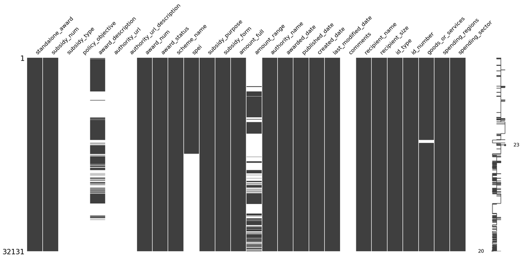

```python
msno.matrix(df)
```

#### General Comments:

- There are no entries in the subsidy type
- Neither in the specific objective and comment
- Missing data seems to be less correlated with one another - might highlight that in comparison to the other dataset, there has been less error in record keeping
- More data is clearly fully available

### Looking more into specifics:

##### Starting with amounts granted:

```python
df['amount_full'].head(20)
```

```
0          18,500
1         121,000
2       5,863,818
3          50,000
4         100,000
5         169,578
6      17,667,075
7         157,500
8         100,000
9         100,000
10        475,000
11         84,000
12        100,000
13     13,000,000
14    396,000,000
15        100,000
16      2,000,000
17      2,713,500
18        100,000
19        100,000
Name: amount_full, dtype: object
```

Fixing this in a similar fashion:

```python
df['amount_full'] = df['amount_full'].str.replace(',', '', regex=False)
df['amount_full'] = pd.to_numeric(df['amount_full'], errors='coerce')
```

```python
#Quick sample of the top 20 amounts

top_amounts = df['amount_full'].sort_values(ascending=False).head(20)
print(top_amounts)
```

```
29549    22000000000
10657    10051000000
12772     9540000000
10653     7000000000
1785      6000000000
12759     4245000000
27864     4185000000
12773     3925000000
2178      2700000000
27865     2295000000
27866     2255000000
27867     1775000000
19935     1300000000
12769     1215000000
12771     1215000000
12770     1215000000
10288     1200000000
26303     1057736053
982        740788200
22962      733688550
Name: amount_full, dtype: int64
```

Unlike last time, the highest amount is 22bn not 4.9t

```python
df['amount_full'].sort_values(ascending = True).head(5)
```

```
5818    0
5826    0
5811    0
5812    0
5813    0
Name: amount_full, dtype: int64
```

Interesting, there are values of 0 - would be interesting to rationale a reason behind this;

```python
zero_amount = df[df['amount_full'] == 0]
```

```python
columns_to_check = [
    'subsidy_type', 'award_status', 'scheme_name', 'recipient_size',
    'subsidy_purpose', 'subsidy_form', 'authority_name'
]

for col in columns_to_check:
    print(f"\nValue counts for '{col}' in zero_amount:")
    print(zero_amount[col].value_counts(dropna=False))

print("\nDistribution of 'awarded_date' in zero_amount:")
print(zero_amount['awarded_date'].value_counts().sort_index())
```

```
Value counts for 'subsidy_type' in zero_amount:
subsidy_type
NaN    7517
Name: count, dtype: int64

Value counts for 'award_status' in zero_amount:
award_status
Published    7517
Name: count, dtype: int64

Value counts for 'scheme_name' in zero_amount:
scheme_name
Small or medium-sized enterprise (SME) R&D tax relief                                                                4545
Enterprise Investment Scheme                                                                                         1853
The Climate Change Agreement                                                                                          465
Theatre Tax Relief                                                                                                    261
Enterprise Management Incentives                                                                                      229
Orchestra Tax Relief                                                                                                   44
Museums and Galleries Exhibition Tax Relief                                                                            30
Venture Capital Trust scheme (previously SA. 33849)                                                                    23
English Freeports Subsidy Scheme                                                                                       22
First-year allowances for expenditure on zero-emission goods vehicles                                                  18
Business Rates Relief: 2023/24 Retail, Hospitality and Leisure Relief Scheme                                            9
Retail, Hospitality & Leisure Relief                                                                                    5
First-year allowances for expenditure on plant and machinery in designated assisted areas within enterprise zones       5
Business Rates Relief: 2024/25 Retail, Hospitality and Leisure Relief Scheme                                            3
Business Rates Relief: 2023/24 Retail, Hospitality and Leisure Scheme                                                   2
Extension of the exemption from the climate change levy for certain forms of transport                                  1
British International Investment (BII)                                                                                  1
AI Awards                                                                                                               1
Name: count, dtype: int64

Value counts for 'recipient_size' in zero_amount:
recipient_size
SME                                      5995
Large                                     314
Small (between 10 and 49 employees)       312
Medium (between 50 and 249 employees)     285
Micro (fewer than 10 employees)           172
Large (more than 250 employees)           165
```

[output cut: 43 more lines]

```

Distribution of 'awarded_date' in zero_amount:
awarded_date
01 April 2023        11
01 April 2024         8
01 August 2023       45
01 December 2022      2
01 December 2023     23
                   ...
31 March 2023       189
31 May 2022           3
31 May 2023          62
31 October 2022       4
31 October 2023      27
Name: count, Length: 667, dtype: int64
```

- **It seems the main culprit is HMRC, recording 7493 out of the 7517 0 amount entries**
- **4545 Small or medium-sized enterprise (SME) R&D tax relief**
- **All but 1 are tax measures**
- **4546 out of 7517 was for research and development**

```python
#Out of all of HMRC, the proportion of 0 amount:

hmrc = df[df['authority_name'] == 'HMRC']
zero_proportion = (hmrc['amount_full'] == 0).mean()

print("Proportion of 0:", zero_proportion)
```

```
Proportion of 0: 0.9995997865528282
```

That is pretty much all of them

```python
hmrc['amount_full'].unique()
```

```
array([     0, 723132, 108191, 109848])
```

```python
non_zero_hmrc = hmrc[hmrc['amount_full'] != 0]
```

```python
non_zero_hmrc
```

|  | standalone_award | subsidy_num | subsidy_type | policy_objective | award_description | authority_url | authority_url_description | award_num | award_status | scheme_name | ... | created_date | last_modified_date | comments | recipient_name | recipient_size | id_type | id_number | goods_or_services | spending_regions | spending_sector |
| --- | --- | --- | --- | --- | --- | --- | --- | --- | --- | --- | --- | --- | --- | --- | --- | --- | --- | --- | --- | --- | --- |
| 17435 | No | SC11086 | NaN | NaN | Zero-rate of secondary National Insurance cont... | NaN | NaN | 17576 | Published | English Freeports Subsidy Scheme | ... | 26 June 2024 | 26 June 2024 | NaN | SIEMENS GAMESA RENEWABLE | Large (250 or more employees) | Company Registration Number | 10253129 | Goods | Yorkshire and Humber | Manufacturing |
| 17437 | No | SC11086 | NaN | NaN | Zero-rate of secondary National Insurance cont... | NaN | NaN | 17577 | Published | English Freeports Subsidy Scheme | ... | 26 June 2024 | 26 June 2024 | NaN | CEVA LOGISTICS LIMITED | Large (250 or more employees) | Company Registration Number | 01291251 | Services | East Midlands | Transportation and storage |
| 17442 | No | SC11086 | NaN | NaN | Zero-rate of secondary National Insurance cont... | NaN | NaN | 17580 | Published | English Freeports Subsidy Scheme | ... | 26 June 2024 | 26 June 2024 | NaN | SIEMENS GAMESA RENEWABLE | Large (250 or more employees) | Company Registration Number | 10253129 | Goods | Yorkshire and Humber | Manufacturing |

3 rows × 28 columns

Wordclouds can be used to analyse what words come up often and therefore can be used to compare two or more samples of data where you think there would be a difference

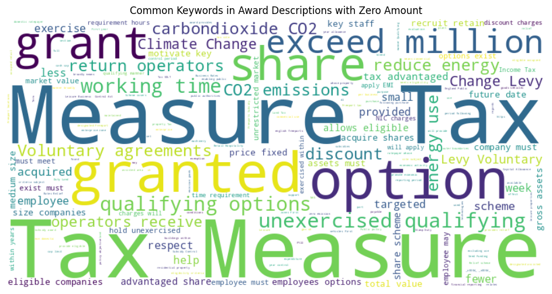

```python
from wordcloud import WordCloud


text1 = ' '.join(zero_amount['award_description'].dropna().astype(str))

wordcloud1 = WordCloud(width=800, height=400, background_color='white', colormap='viridis').generate(text1)

plt.figure(figsize=(12, 6))
plt.imshow(wordcloud1, interpolation='bilinear')
plt.axis('off')
plt.title("Common Keywords in Award Descriptions with Zero Amount")
plt.show()
```